# Intelligence artificielle (IA) : de quoi parle-t-on ? | enseignementsup-recherche.gouv.fr

Publié le 22.05.2024

[figure not shown]

# Intelligence artificielle (IA) : de quoi parle-t-on ?

Abrégée aujourd’hui en IA, l'intelligence artificielle est un enjeu technologique qui intéresse l’économie, la recherche ou la formation et innerve tous les domaines de la société. Faisons le point sur la stratégie française et l’évolution rapide des technologies.

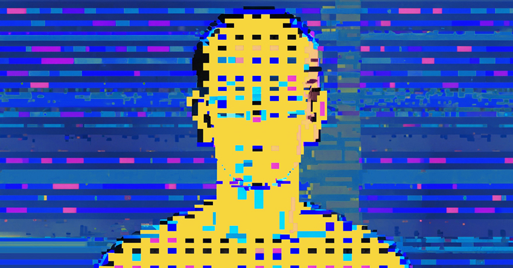

Crédits :

Adobe Firefly AI / MESR

Image générée par intelligence artificielle

## Intelligence artificielle : définition

L'**intelligence artificielle** est une **notion forgée au milieu des années 1950**, dans la foulée des **réflexions du mathématicien Alan Turing**, qui se demandait si un ordinateur saurait un jour "penser", ou s’il n’était capable que d’un "jeu d’imitation" (*imitation game*).

Le **Parlement européen**, quant à lui, définit l’intelligence artificielle comme tout **outil** utilisé par une machine **capable de "reproduire des comportements liés aux humains, tels que le raisonnement, la planification et la créativité"**.

Les champs d'action de l'IA sont vastes et semblent difficiles à circonscrire puisqu'ils s'étendent à de nombreux aspects du quotidien que ce soit pour effectuer des recherches ou des achats en ligne, le ciblage publicitaire, la traduction automatique, les assistants numériques personnels, les villes connectées, mais aussi dans le domaine des transports, de la santé, etc.

A l'heure actuelle, les GPT (*Generative Pre-trained Transformers*) ou modèles de langage pré-entraînés interrogent en regard de l'utilisation qu'ils font des données et de leurs algorithmes, qui pour la plupart ne sont pas en *open source* (code source ouvert). Le RGPD impose en effet que les données traitées soient exactes, or les intelligences artificielles génératives produisent à partir de celles-ci un contenu qui peut être erroné, qui serait donc non conforme à la réglementation européenne.

## La stratégie française

La stratégie nationale pour l’intelligence artificielle, **lancée en 2018**, fait suite aux **recommandations du rapport Villani**. Elle a permis notamment :

- la création d’un réseau académique d'instituts d’excellence en intelligence artificielle (3IA puis cluster IA),
- le soutien à des chaires d’excellence en IA
- le financement de programmes doctoraux
- la mise à disposition de la recherche française de Jean Zay, un supercalculateur pour l’IA
- la mise en œuvre d’un [programme et équipements prioritaires de recherche en IA](https://www.enseignementsup-recherche.gouv.fr/pepr-intelligence-artificielle-la-recherche-francaise-la-pointe-95298) (PEPR IA)

Objectifs :

- donner un sens à l’intelligence artificielle
- faire de la France un champion mondial de l’intelligence artificielle.

Pour y parvenir, la stratégie nationale comprend **1,5 milliard d'euros mobilisés dans le cadre de France 2030** pour accompagner l’écosystème français, lui permettre de se développer sur des marchés porteurs et de diffuser les usages de l’IA dans l’économie.

**1,5 Md €** mobilisés en faveur de l'intelligence artificielle dans le cadre de France 2030

**En combinant l’excellence de la formation, de la recherche et de l’innovation**, l’objectif est de **faire émerger en France des champions académiques européens et mondiaux dans le champ de l’intelligence artificielle** et de ses applications. Ces synergies entre formation et recherche d’excellence doivent permettre à la France et à l’Europe, dans un espace compétitif international, de constituer des pôles de recherche et de formation de rang européen et mondial, avec un impact significatif sur l’économie.

### Déploiement et financements

Lors du salon Viva Technology 2023, du 14 au 17 juin 2023 à Paris, le président de la République Emmanuel Macron a annoncé un ambitieux [plan de soutien des acteurs de l’intelligence artificielle, financé par France 2030](https://www.enseignementsup-recherche.gouv.fr/fr/france-2030-emmanuel-macron-annonce-un-effort-sans-precedent-de-la-france-en-intelligence-91286). Il comprend le dispositif "IA-cluster", doté de 500 M €, dans le but de consolider des pôles de formation et de recherche d’excellence nationaux et de faire d'eux des champions européens et internationaux.

En mars 2024, après 6 mois de travail, la [commission dédiée à l'intelligence artificielle a rendu son rapport comprenant 25 recommandations](https://www.gouvernement.fr/actualite/25-recommandations-pour-lia-en-france) pour faire de la France un acteur majeur de la révolution technologique de l'intelligence artificielle en général et de l’IA générative en particulier.

- PR[AI]RIE – PSAI (Université Paris Sciences et Lettres) – 75 M€
- MIAI Cluster (Université Grenoble Alpes) – 70 M€
- Hi! PARIS Cluster 2030 (Institut Polytechnique de Paris) –70 M€
- PostGenAI@PARIS (Sorbonne université) – 35 M€
- ENACT (Université de Lorraine) – 30 M€
- DATAIA-Cluster (Université Paris Saclay) – 20 M€
- ANITI IA Cluster (Université de Toulouse) – 20 M€
- 3IA Côte d’Azur 2030 (Université Côte d’Azur) – 20 M€
- SequoIA (Université de Rennes) – 20 M€.

### Résultats

La France est le premier écosystème pour l’IA en Europe

**+ 600** startups en IA (+24% entre 2021 et 2023) dont 50% sont rentables ou envisagent de l’être d’ici 3 ans

**3,2 Md €** levés en 2022 par des entreprises de l’IA

**1<sup>er</sup>** en Europe pour les projets d’investissements étrangers en IA

On compte 76 startups d’IA générative (son, texte, vidéo, image) en France. Les modèles actuels les plus puissants ont été entraînés ou développés en France : Llama 2, Llama 3, Mistral Large.

[France 2030 : l'IA comme un accélérateur et un différentiateur d'innovation](https://www.enseignementsup-recherche.gouv.fr/france-2030-l-ia-comme-un-accelerateur-et-un-differentiateur-d-innovation-96213)

## Interview d'expert : Stéphane Canu

**Stéphane Canu, chargé de mission Intelligence Artificielle au sein du ministère de l'Enseignement supérieur et de la Recherche**, répond à nos questions.

### Quelles sont les priorités fixées dans la stratégie nationale en intelligence artificielle ?

**Stéphane Canu :** La stratégie d’accélération en IA (parfois appelée phase 2 du plan IA, menée dès 2021), qui dispose d'un budget de **1,5 milliard d'euros de fonds publics**, est intitulée : **"diffuser l'IA dans l'économie"**. Il s'agit à présent de porter l'attention sur les produits de l'IA, donc sur le marché, la demande, le besoin, les usages et contraintes d'usage, la concurrence, les coûts et les prix, les éventuels monopoles ou verrous commerciaux. Une vision qui nous oblige à faire des choix stratégiques par nature risqués liés à plusieurs objectifs :

- le maintien de la recherche française en IA au meilleur niveau international,
- le redressement économique, singulièrement de la balance commerciale, donc à la production de valeur exportable,
- la reconquête de notre indépendance stratégique et de notre souveraineté, donc à la production de valeur pour nos besoins domestiques,
- le bien-être individuel et social, au progrès de l'humanité, y compris au plan de la connaissance scientifique, de l'inclusion, de la justice, de la qualité de vie, etc.
- la durabilité de ces modèles, à la sauvegarde de ressources naturelles limitées et des libertés des futures générations.

Des choix stratégiques de filières ont été faits, après avoir été débattus, en l'occurrence de porter un effort particulier sur **l'embarquabilité, la frugalité, la confiance et l'IA générative**, avec une attention particulière portée sur l’émergence de projets open source, ouverts sur l’écosystème scientifique et des acteurs innovants. **La France a toujours fait le pari de l’open source** pour mettre à disposition du plus grand nombre des briques technologiques pour favoriser le développement des innovations nécessaires aux entreprises et aux administrations. La bibliothèque d’apprentissage automatique Scikit-learn créée en 2006 par Inria en est un excellent exemple : elle est la troisième bibliothèque la plus utilisée au monde après celles proposées par Google et Meta.

[Scikit-learn](https://scikit-learn.org/stable/) créée en 2006 par Inria, est la troisième bibliothèque d’apprentissage automatique la plus utilisée au monde

### Quels en sont les principaux acteurs ?

S. C. :Les principaux acteurs de l’intelligence artificielle en France sont :

- les [grands groupes réunis au sein du manifeste de l’IA](https://www.thalesgroup.com/fr/group/journaliste/press-release/ai-humanity-industriels-francais-sengagent-lintelligence)
- les [start-up de l’IA (590), les licornes, la french tech associée et des lieux emblématiques à l'instar de station F](https://francedigitale.org/publications/mapping-startups-ia)
- les instituts de transfert de technologies comme les IRT saint Exupéry à Toulouse et SystemX à Saclay
- les acteurs académiques de la formation et de la recherche : les 3 ONR (Inria, CNRS et CEA), les universités et les écoles, notamment présentes dans le quatre instituts interdisciplinaires d’intelligence artificielle (3IA bientôt rebaptisé Cluster IA) localisés à Nice (Côte d’Azur), Toulouse (ANITI), Grenoble (MIAI) et Paris (PRAIRIE)
- et bien sûr, à l’international, les géants de la tech : les GAMAM (Facebook étant devenu Meta) et autres BATX.

Plus que ces acteurs, c’est tout un écosystème structuré et développé depuis [le rapport Villani autour de l’IA](https://www.enseignementsup-recherche.gouv.fr/fr/rapport-de-cedric-villani-donner-un-sens-l-intelligence-artificielle-ia-49194) qui a permis l’effervescence que l’on constate aujourd’hui autour de l’IA française.

### L’IA peut-elle aider d’autres domaines de recherche ? Comment ?

S. C. : L’intelligence artificielle est un champ de recherche en soi mais aussi un accélérateur de la découverte scientifique dans de nombreux domaines à condition de favoriser le rapprochement entre les différentes communautés scientifiques. L’IA peut aider dans de nombreux domaines de recherche en apportant des capacités avancées de traitement des données, d'analyse et de modélisation. C’est le cas par exemples dans les domaines de :

- la santé, où l’IA est un des piliers du [PEPR santé numérique](https://www.inserm.fr/actualite/sante-numerique-quand-la-recherche-monte-en-puissance/) : l’IA est appelée à jouer un rôle central dans la révolution médicale en cours. Issues du secteur médical et des patients, avec l’avènement des objets connectés de santé, les données de santé permettent d’améliorer considérablement les diagnostics de nombreuses pathologies.
- l’environnement : le [service Prioréno](https://www.banquedesterritoires.fr/la-banque-des-territoires-lance-en-partenariat-avec-letat-enedis-et-grdf-le-service-data-prioreno) est une intelligence artificielle qui aide les collectivités à la rénovation thermique de leurs bâtiments publics.
- l’histoire où l’IA aide à [explorer les archives de Notre-Dame de Paris](https://theconversation.com/explorer-les-archives-de-notre-dame-de-paris-grace-a-lintelligence-artificielle-202871)
- le transport à travers l'aide à la conduite et les véhicules autonomes.

Dans le cadre de son plan stratégique sur l'Intelligence Artificielle, [le CNRS a lancé son centre IA pour la Science et Science pour l'IA (AISSAI)](https://www.cnrs.fr/fr/le-centre-artificial-intelligence-science-science-artificial-intelligence-aissai). L'objectif principal de ce centre est de structurer et d’organiser les actions transverses impliquant l’ensemble des instituts du CNRS aux interfaces avec l’IA.

### Bloom, projet de science ouverte et participative produit par le consortium international BigScience, gère plus de 46 langues et serait le plus grand modèle de langage open source au monde, il a été présenté comme une alternative open source à ChatGPT, fondé par l'entreprise américaine OpenAI. Est-ce toujours le cas ?

S. C. : Après GTP-3, le modèle génératif d’OpenAI de plus de 200 milliards de paramètres, Bloom a été le premier modèle analogue open source, entrainé en France grâce au super calculateur public Jean Zay. Il a permis des applications mais n'a pas su évoluer aussi rapidement que ChatGPT qui est passé rapidement à la version 3.5 puis 4 et bientôt 5. De plus, la communauté s’est accordée à dire que "200 milliards de paramètres, c’était trop".

Ce type de modèle génératif forme le cœur des IA conversationnelles comme ChatGPT, sorti en novembre 2022 complètement sous licence privée. Trois mois après, en février 2023, Meta, a annoncé la sortie de son propre modèle de langage open source, LLaMA pour Large Language Model Meta AI. Ce modèle et ses successeurs intégrés sont capables de rivaliser voire de surpasser GPT tout en occupant beaucoup moins d'espace mémoire (5 à 20 fois moins). Mais Meta est allé encore plus loin en publiant les détails de son algorithme LLaMA, ainsi que "la recette" nécessaire pour l'utiliser, ce qui permet à tout un chacun de l'exploiter dans ses propres applications.

La France n'est pas en reste avec la start-up Mistral AI qui a produit des modèles Mistral parmi les meilleurs au monde. Tous ces modèles sont disponibles sur la plateforme de la société [HuggingFace](https://huggingface.co/).

Aujourd’hui, ces assistants conversationnels comme ChatGPT, Gemini, Bard (son homologue de chez Google) ou Le chat (développé en France par Mistral AI), peuvent être vus comme une nouvelle génération de moteurs de recherche, plus interactifs, capables de dialoguer avec son utilisateur. L’utilisateur sait bien que ce dialogue est souvent nécessaire car le taux de bonnes réponses en première intention de ces IA conversationnelles est aujourd'hui de l'ordre de 32 % sur le [benchmark GAIA](https://huggingface.co/spaces/gaia-benchmark/leaderboard).

### Quels bénéfices directs la société française et la population peuvent-elles espérer de l’IA ?

S. C. : L'IA peut contribuer à l'amélioration des soins de santé en permettant un diagnostic précoce, une personnalisation des traitements, une analyse précise des données médicales et une assistance aux professionnels de la santé. L'IA peut également aider à la surveillance de la santé à domicile, à la détection des changements et à la prévention des maladies.

L'intelligence artificielle peut jouer un rôle dans l'amélioration de la mobilité en facilitant la gestion du trafic, la planification des itinéraires, la conduite autonome et la réduction des accidents de la route. Elle peut également contribuer à l'optimisation des réseaux de transport en prédisant la demande et en proposant des solutions de transport plus efficaces.

L'intelligence artificielle peut stimuler l'innovation, la productivité et la compétitivité économique (par exemple dans le domaine informatique où elle aide à produire du code). Elle peut créer de nouvelles opportunités d'emploi pour le développement de technologies, l'analyse de données et la gestion des systèmes d'IA. Cependant, elle peut également entraîner des changements dans certains secteurs d'emploi, nécessitant une adaptation et une reconversion professionnelle. L'IA va impacter les méthodes d'enseignement et de formation en permettant une personnalisation de l'apprentissage, en fournissant des ressources éducatives adaptées aux besoins individuels. L'IA peut également aider à l'identification des lacunes dans les connaissances des élèves et à la fourniture de rétroactions personnalisées.

> L'intelligence artificielle va impacter les méthodes d'enseignement et de formation en permettant une personnalisation de l'apprentissage, en fournissant des ressources éducatives adaptées aux besoins individuels.

Stéphane Canu, MESR

### Quels sont les écueils à éviter selon vous ?

S. C. : Avant tout, il ne faut ni surinterpréter les résultats de l’intelligence artificielle, ni sous-estimer ses apports. Les autres écueils seraient de ne pas maitriser les technologies associées, de méconnaitre les biais inhérents à son mode de programmation et notamment aux données utilisées pour entraîner les IA d’aujourd’hui. Il faut au contraire **maîtriser les enjeux environnementaux, avoir une approche responsable et éthique des usages de l’IA**.  
Ces enjeux sont abordés par les efforts de régulation notamment au niveau européen à travers l’IA act, par le « AI Safety Summit », le Partenariat mondial sur l'intelligence artificielle (PMIA ou GPAI) et traités dans la déclaration de Montréal pour un développement responsable de l’intelligence artificielle qui poursuit trois objectifs :

1. **élaborer un cadre éthique** pour le développement et le déploiement de l’IA ;
2. **orienter la transition numérique** afin que tous puissent bénéficier de cette révolution technologique ;
3. ouvrir un espace de dialogue national et international pour réussir collectivement un **développement inclusif, équitable et écologiquement soutenable**.

Intialement publié le 13 juin 2023 ; mis à jour le 22 mai 2024.

## Aller plus loin

- [Comment l’intelligence artificielle va changer nos vies | CNRS le journal](https://lejournal.cnrs.fr/dossiers/comment-lintelligence-artificielle-va-changer-nos-vies)
- [La stratégie nationale pour l'IA | Entreprises.gouv.fr](https://www.entreprises.gouv.fr/fr/numerique/enjeux/la-strategie-nationale-pour-l-ia)
- [France 2030 : Lancement de nouveaux dispositifs dans le cadre de la stratégie nationale en intelligence artificielle | Gouvernement.fr](https://www.gouvernement.fr/france-2030-lancement-de-nouveaux-dispositifs-dans-le-cadre-de-la-strategie-nationale-en)

Publié le *22.05.2024*

## **Voi**r aussi

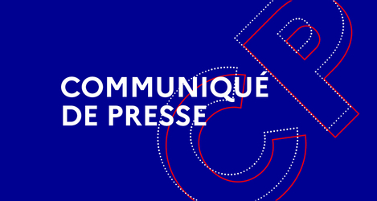

### [France 2030 : l'IA comme un accélérateur et un différentiateur d'innovation](https://www.enseignementsup-recherche.gouv.fr/fr/france-2030-l-ia-comme-un-accelerateur-et-un-differentiateur-d-innovation-96213)

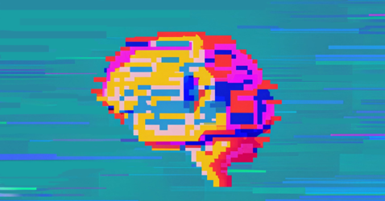

### [PEPR intelligence artificielle : la recherche française à la pointe](https://www.enseignementsup-recherche.gouv.fr/fr/pepr-intelligence-artificielle-la-recherche-francaise-la-pointe-95298)

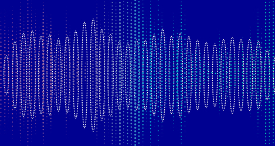

### [Stratégie nationale de recherche en intelligence artificielle](https://www.enseignementsup-recherche.gouv.fr/fr/strategie-nationale-de-recherche-en-intelligence-artificielle-51110)

[figure not shown]